# HAH913E-Physical-activity-00: Assignment

04 October 2025, 13:12:59

**Table of contents**

- 1. Plot ENMO integrated over epoch for varied epochs
- 2. The assignment:

# 1. Plot ENMO integrated over epoch for varied epochs

You have to create a Jupyter Notebook to plot ENMO integrated over epoch for varied epochs. You can work in teams, using one branch per person.

The data set is a few minutes of raw accelerometer data from a wrist-worn accelerometer (Axivity AX3) worn on the non-dominant wrist. The file `0_z.csv` contains 4 columns: t (in seconds), x, y, z (in g).

You should be able to produce the following plots for epoch lengths of 10s, 30s, and 60s.:

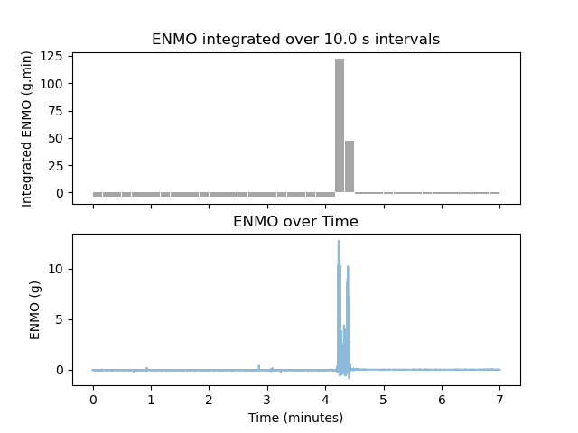

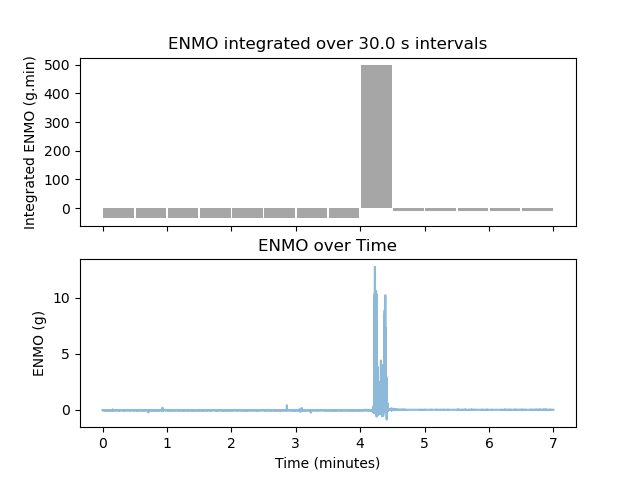

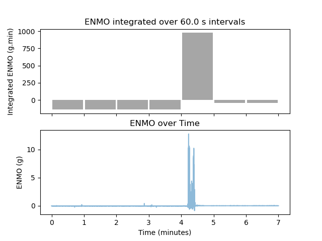

# 2. The assignment:

Your mission, should you choose to accept it, is to:

- Explain the **reasoning** behind the main steps of your notebook in **markdown cells**.
- Use **functions** to structure your code.
- Merge your team works into a single branch and create a **pull request** to the main branch.
- Provide the URL of your GitHub repository (public repository) so that I can see **how you proceeded**.
- Provide the prompts you used to get Copilot's suggestions, and what you **changed** after reviewing them.
- In the first notebook cell, provide
  - the URL of your GitHub repository (as a clickable link).
  - the name of the team members who worked on this assignment.
- Export your notebook in HTML format ([how?](https://code.visualstudio.com/docs/datascience/jupyter-notebooks)) and upload it to Moodle.